# Follow-up meeting (20200506)

Youchen

5/6/2020

# Study Area

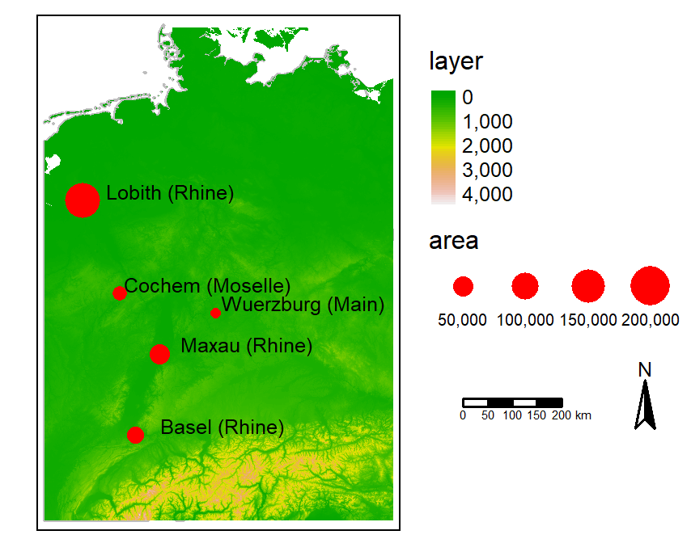

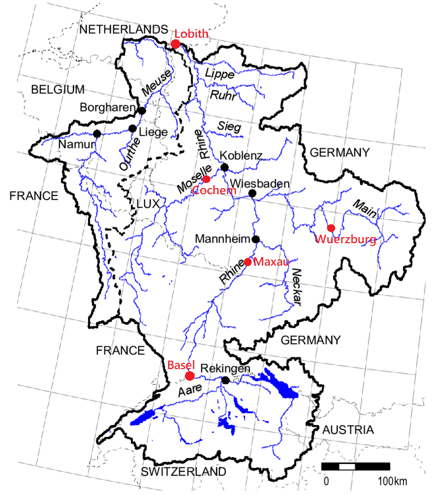

# Model Framework

res = f(input variables, pcr state variables)

- res = observations - pcrglob predictions
- predictors:
  - Sign of the residuals (-/+)
  - Days in the year (1~365/366)
  - Input variables:
    - precipitation (p)
    - temperature (t)
    - reference potential evapotranspiration (et)
  - State variables:

[output not shown]

# Using default pcr parameters

# KGE and RMSE

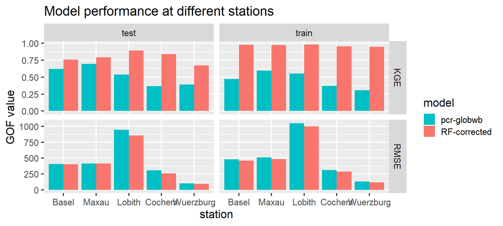

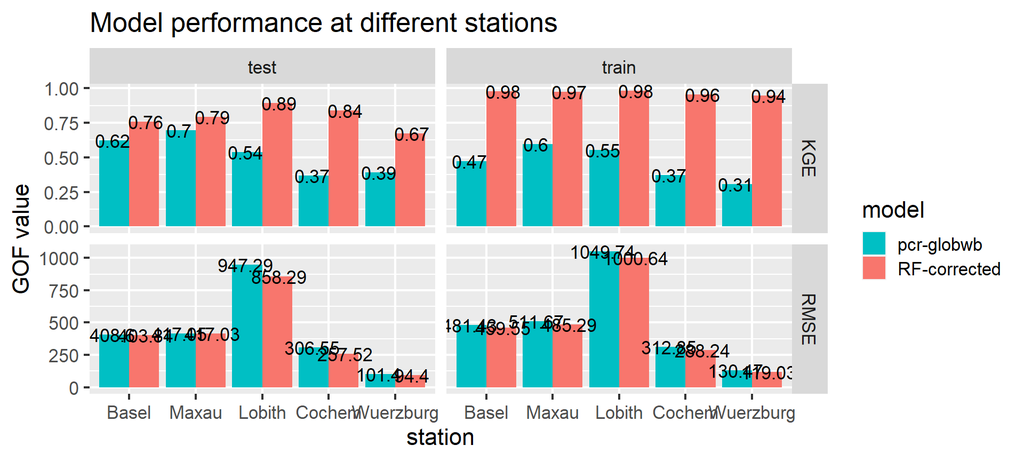

# Variable importance and correlations between predictors and residuals

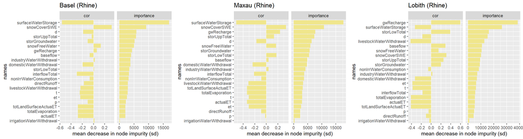

# Variable importance and correlations between predictors and residuals

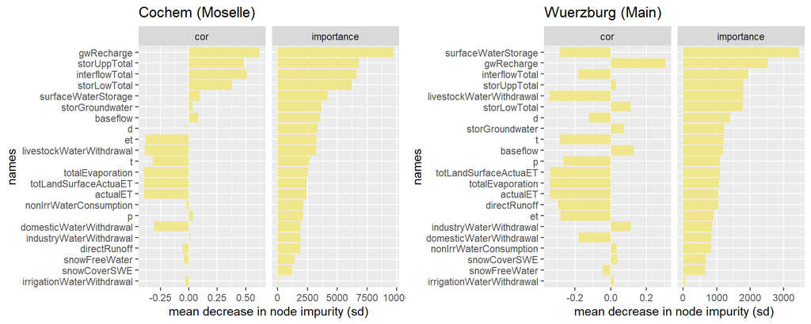

# Related studies:

1. Snieder, E., Shahmansouri, A., Cheng, C.-H., Ding, Y., Graham, E., & Khan, U. (2020). “Improved real-time SWMM flow forecasts using two machine learning approaches.” Paper presented at the EGU General Assembly 2020, Vienna, Austria.
- SWMM-ANN hybrid model: ANN corrects SWMM predictions with a lead time of 4-hour. They use SWMM flow predictions and lagged (i.e., 1 to 24-hour lag time) rainfall and observed flow time-series as predictors to predict the difference between SWMM forecasts and flow observations.
2. C. Kurian, K. P. Sudheer, V. Krishna Vema, and D. Sahoo, “Effective flood forecasting at higher lead times through hybrid modelling framework,” J. Hydrol., p. 124945, Apr. 2020.
- A ANN model was built by predictors of lagged precipitation observations, lagged streamflow observations, and lagged streamflow predictions from two semi-distributed hydrological models (HEC-HMS & SWAT) to predict real-time streamflow.
3. C. C. Young, W. C. Liu, and M. C. Wu, “A physically based and machine learning hybrid approach for accurate rainfall-runoff modeling during extreme typhoon events,” Appl. Soft Comput. J., vol. 53, pp. 205–216, Apr. 2017.
- A hybrid model (M4) that combines the strength of a physically-based distributed hydrological model and a data-driven model (ANN), was developed.

# Extra Information